# Unit 9 - Simulations and Standard Errors

James Flynn

October 5, 2026

## Load up some packages we’ll be using

```r
library(plotrix)
library(ggplot2)
library(lmtest)
library(sandwich)
library(reshape)
library(tidyverse)
```

## Simulation

- Simulations help us see what’s under the hood
- We create fake data where **we control** the DGP
- We know how estimators **should** behave
- If our estimators break in a controlled environment, how will they perform in the wild?
- We can repeat this random process thousands of times to separate fluke occurrences from actual problems

## So how do we simulate?

- We set up a DGP
- Use a random number generator to create data
- Apply the estimator we are interested in using
- Store our estimate
- Repeat steps 2-4 **a lot** of times
- Look at the distribution of estimates

## Let’s start by playing around with the normal distribution

```r
set.seed(745872)
#draw 20 observations from the normal distribution
sim_norm_20 <- rnorm(20)
#now 100
sim_norm_100 <- rnorm(100)
#now 10,000
sim_norm_10000 <- rnorm(10000)
```

## Now let’s plot them

- First 20

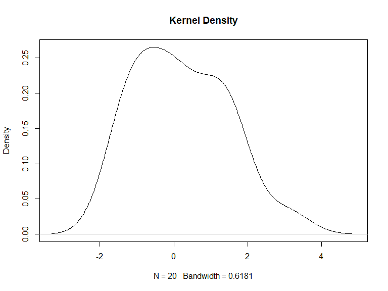

```r
plot(density(sim_norm_20), main="Kernel Density")
```

## Now 100

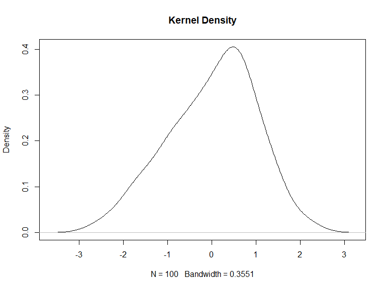

```r
plot(density(sim_norm_100), main="Kernel Density")
```

## And 10,000

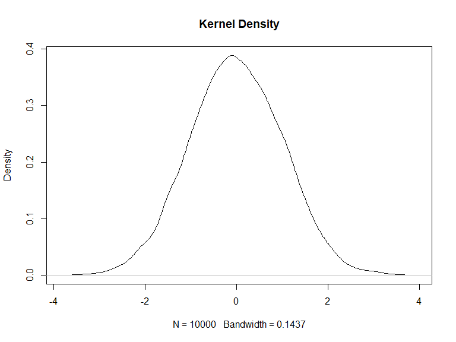

```r
plot(density(sim_norm_10000), main="Kernel Density")
```

## What do we notice?

- Clearly they are looking more like a normal distribution as N $\uparrow$
  - Why is that?

## How many of each draw will be above 2 in absolute value?

- What’s the rule here?
  - for 20?
  - 100?
  - 10,000?

## Let’s look

```r
n_20 <- sum(abs(sim_norm_20)>2)
n_100 <- sum(abs(sim_norm_100)>2)
n_10000 <- sum(abs(sim_norm_10000)>2)
n_20
```

```
## [1] 1
```

```r
n_100
```

```
## [1] 4
```

```r
n_10000
```

```
## [1] 464
```

## What if we use 1.96

```r
n_20 <- sum(abs(sim_norm_20)>1.96)
n_100 <- sum(abs(sim_norm_100)>1.96)
n_10000 <- sum(abs(sim_norm_10000)>1.96)
n_20
```

```
## [1] 1
```

```r
n_100
```

```
## [1] 5
```

```r
n_10000
```

```
## [1] 511
```

## Let’s calculate the standard **error** for each of these

- First, we need the sample standard deviation

$$\text{Standard Deviation} = \sigma =
\sqrt{\frac{\sum{(x-\bar{x})^2}}{(n-1)}}$$

$$\text{Variance} = \sigma^2$$

$$\text{Standard Error of the Mean} =
\frac{\sigma}{\sqrt{n}}$$

## Std. Dev. vs. Std. Error Intuition

- Std. Dev. measures the variability of data *within* a sample
  - Does not necessarily decrease with larger *n*
- Std. Error measures variability of sample means across *different* samples
  - Larger *n* gives us more confidence that we are close to the population mean
  - Will get more precise as *n* increases

## Calculating standard deviation manually

```r
sum_sq_dif_20 <- sum((sim_norm_20 - mean(sim_norm_20))^2)
sum_sq_dif_20_div_N <- sum_sq_dif_20/(length(sim_norm_20)-1)
#now take the square root of this object
standard_deviation_20 <- sqrt(sum_sq_dif_20_div_N)
standard_deviation_20
```

```
## [1] 1.250304
```

## Notice that it’s not equal to 1

It’s good to know how to calculate this, but R can do it:

```r
sd(sim_norm_20)
```

```
## [1] 1.250304
```

```r
sd(sim_norm_100)
```

```
## [1] 0.9910327
```

```r
sd(sim_norm_10000)
```

```
## [1] 1.007293
```

## Now for the standard error

$$StandardError = \frac{\sigma}{\sqrt{n}}$$

```r
standard_error_20 <- standard_deviation_20/sqrt(length(sim_norm_20))
standard_error_20
```

```
## [1] 0.2795765
```

R also has a function that will do all this for us

```r
std.error(sim_norm_20)
```

```
## [1] 0.2795765
```

## Standard Errors will get smaller as N goes up

```r
std.error(sim_norm_20)
```

```
## [1] 0.2795765
```

```r
std.error(sim_norm_100)
```

```
## [1] 0.09910327
```

```r
std.error(sim_norm_10000)
```

```
## [1] 0.01007293
```

Whereas standard deviations get more tightly clustered around the mean

## Let’s demonstrate

- First with standard deviations

```r
#create empty data frame to store results ins
df <- data.frame(matrix(ncol=2,nrow=1000))
colnames(df) <- c("sd_bigN","sd_smallN")
#create loop that takes 1,000 samples
for(i in 1:nrow(df)) {
bigN <- rnorm(1000)
smallN <- rnorm(10)
#store standard deviation from each
df[i,1] <- sd(bigN)
df[i,2] <- sd(smallN)
  }
```

## Now we compare the distributions

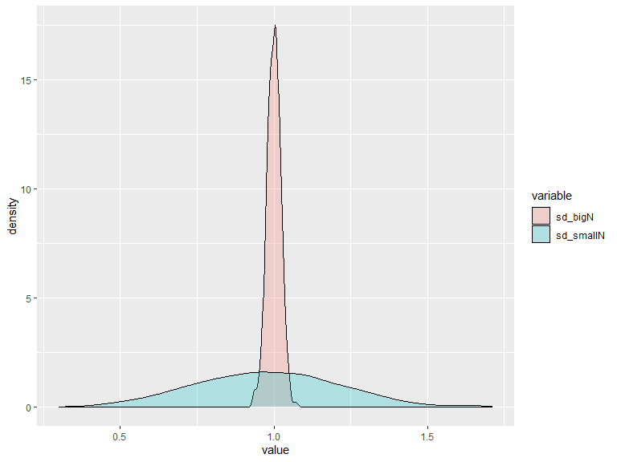

```r
data <- melt(df)
ggplot(data, aes(x=value, fill=variable)) +
  geom_density(alpha=.25)
```

## Repeat this with standard errors

```r
#create empty data frame to store results ins
df <- data.frame(matrix(ncol=2,nrow=1000))
colnames(df) <- c("se_bigN","se_smallN")
#create loop that takes 1,000 samples
for(i in 1:nrow(df)) {
bigN <- rnorm(100)
smallN <- rnorm(10)
#store standard error from each
df[i,1] <- sd(bigN)/(sqrt(length(bigN)))
df[i,2] <- sd(smallN)/(sqrt(length(smallN)))
  }
```

## Now we compare the distributions

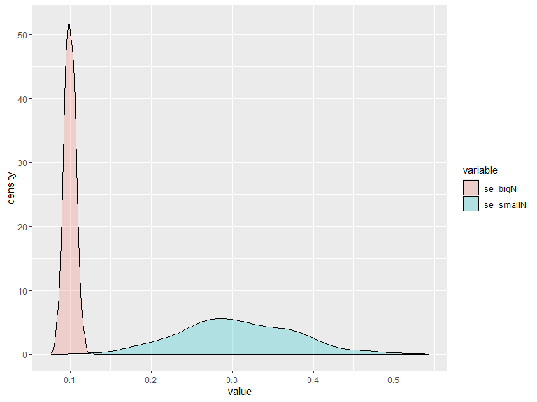

```r
data <- melt(df)
ggplot(data, aes(x=value, fill=variable)) +
  geom_density(alpha=.25)
```

## Class exercise

- Looking at the uniform $[0,1]$ distribution
  - What % of observations fall below .1?
  - Should be 10%
- Write a simulation that takes two samples from the uniform distribution
  - One with 10 observations
  - One with 1000
  - Each round: save the fraction of observations <.1
  - Do this 1000 times
  - Plot the distribution

## Answer

```r
#create empty data frame to store results ins
df <- data.frame(matrix(ncol=2,nrow=1000))
colnames(df) <- c("uni_bigN","uni_smallN")
#create loop that takes 1,000 samples
for(i in 1:nrow(df)) {
bigN <- runif(1000)
pct_below_bigN <- length(bigN[bigN<.1])/1000
smallN <- runif(10)
pct_below_smallN <- length(smallN[smallN<.1])/10

#store standard deviation from each
df[i,1] <- pct_below_bigN
df[i,2] <- pct_below_smallN
  }
```

## Plotted

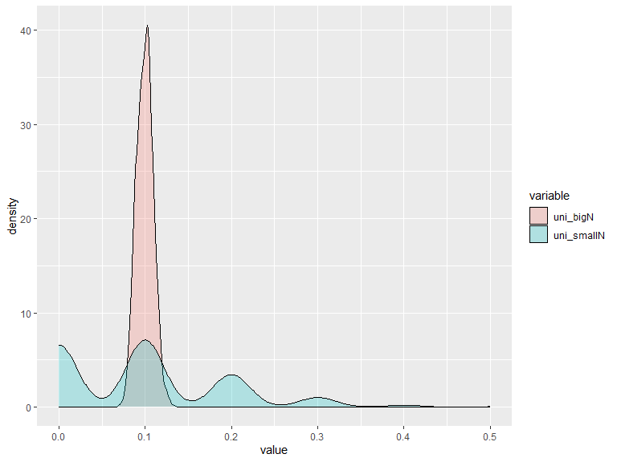

```r
data <- melt(df)
ggplot(data, aes(x=value, fill=variable)) +
  geom_density(alpha=.25)
```

## What is this simulation doing?

```r
prob_best_team_wins_game <- .55

world_series <- data.frame(matrix(ncol=1,nrow=1000))
colnames(world_series) <- c("best_team_won_series")

for(i in 1:nrow(world_series)) {
temp_df <- data.frame(matrix(ncol=1,nrow=7))
temp_df <- temp_df %>%
  mutate(game_outcome = runif(7),
         best_team_won_game = game_outcome < prob_best_team_wins_game)
world_series[i,1] <- sum(temp_df$best_team_won_game)>=4
}
sum(world_series$best_team_won_series)/nrow(world_series)
```

```
## [1] 0.622
```

## Class exercise

- How often will the best team win:
  - A three game series
  - With a 57% likelihood of winning each game

## Solution

```r
prob_best_team_wins_game <- .57
num_games <- 3

world_series <- data.frame(matrix(ncol=1,nrow=1000))
colnames(world_series) <- c("best_team_won_series")

for(i in 1:nrow(world_series)) {
temp_df <- data.frame(matrix(ncol=1,nrow=num_games))
temp_df <- temp_df %>%
  mutate(game_outcome = runif(3),
         best_team_won_game = game_outcome < prob_best_team_wins_game)
world_series[i,1] <- sum(temp_df$best_team_won_game)>=2
}
sum(world_series$best_team_won_series)/nrow(world_series)
```

```
## [1] 0.573
```

## Earlier we talked about **standard error** of the **mean**

- Is that what we are looking at when we run regressions?
  - Close, but not quite. Remember:

$$\text{Standard Deviation} = \sigma =
\sqrt{\frac{\sum{(x-\bar{x})^2}}{(N-1)}}$$

$$\text{Variance} = \sigma^2$$

$$\text{Standard Error of the Mean} =
\frac{\sigma}{\sqrt{n}}$$

## What about standard deviation of $\beta_1$

- Same idea, slightly different execution:

$$V(\hat{\beta_1}) =
\frac{\sigma^2}{SST_x}$$

where

$$\sigma = \text{variance of the error
term}$$

$$SST_x = \sum
(x_i-\bar{x})^2$$

## As before, $SD(\hat{\beta_1}) = \sqrt(V(\hat{\beta_1}))$

$$SD(\hat{\beta_1}) =
\sqrt(\frac{\sigma^2}{SST_x})$$

$$\equiv
\frac{\sigma}{\sqrt(SST_X)}$$

- but we don’t actually observe $\sigma$
- we can estimate it using $\hat{u}$

## Estimating $\sigma$

$$\hat{\sigma} =
\sqrt(\frac{SSR}{(n-2)})$$

this gives us an estimate of the variance in the error term

## Finally, the standard errors we see

$$SE(\hat{\beta_1}) =
\frac{\hat{\sigma}}{\sqrt(SST_x)}$$

- Which shows us that there are two ways to influence our SE’s
- Important to remember this estimate is consistent only under the assumptions we have made

## Can simulations help us understand regressions?

- Every regression we run has **assumptions** baked in
- It can be hard to know whether these assumptions hold
- It is also hard to tell how bad it would be if they didn’t
- What will happen if I create two fake variables with no correlation, and regress one on the other?

## Random regression

```r
set.seed(9)
x <- rnorm(1000)
y <- rnorm(1000)
lm1 <- lm(y ~ x)
summary(lm1)
```

```
##
## Call:
## lm(formula = y ~ x)
##
## Residuals:
##     Min      1Q  Median      3Q     Max
## -3.2969 -0.6785 -0.0124  0.6918  3.2155
##
## Coefficients:
##             Estimate Std. Error t value Pr(>|t|)
## (Intercept) -0.01098    0.03130  -0.351   0.7258
## x           -0.06694    0.03262  -2.052   0.0404 *
## ---
## Signif. codes:  0 '***' 0.001 '**' 0.01 '*' 0.05 '.' 0.1 ' ' 1
##
## Residual standard error: 0.9898 on 998 degrees of freedom
## Multiple R-squared:  0.004202,   Adjusted R-squared:  0.003204
## F-statistic: 4.211 on 1 and 998 DF,  p-value: 0.04041
```

## Ruh Roh…What happened?

- Did we do something wrong?
- Is this what we call **spurious**
- How can we figure this out?

## Simulations using regressions

```r
#create empty data frame to store results ins
df <- data.frame(matrix(ncol=1,nrow=1000))
colnames(df) <- c("p_value")
#create loop that runs this regression 1,000 times
for(i in 1:nrow(df)) {
x <- rnorm(1000)
y <- rnorm(1000)
lm2 <- lm(y ~ x)
#store the p-value from each estimate in df
df[i,1] <- summary(lm2)$coefficients[2,4]
  }
```

## Now we can see how many regressions were significant

```r
sum(df$p_value<.05)
```

```
## [1] 44
```

Turns out, this is about what we would expect to happen by chance.

## Back to our example. Let’s go 10,000 times

```r
df <- data.frame(matrix(ncol=1,nrow=10000))
colnames(df) <- c("p_value")
for(i in 1:nrow(df)) {
  x <- rnorm(1000)
  y <- rnorm(1000)
  lm2 <- lm(y ~ x)
  df[i,1] <- summary(lm2)$coefficients[2,4]
}
```

```r
sum(df$p_value<.05)
```

```
## [1] 503
```

## What about other p-values?

```r
sum(df$p_value<.07)
```

```
## [1] 710
```

```r
sum(df$p_value<.21)
```

```
## [1] 2117
```

```r
sum(df$p_value<.62)
```

```
## [1] 6253
```

## It turns out the p-values here are uniformly distributed

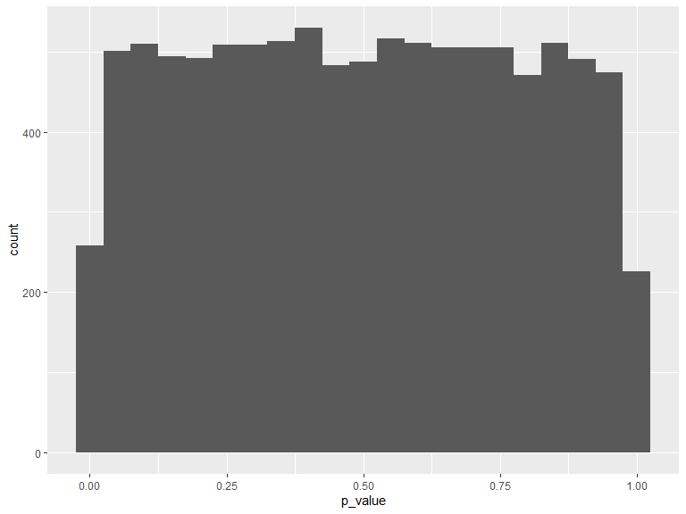

```r
ggplot(df,aes(x=p_value)) +
  geom_histogram(binwidth = .05, start=0)
```

## This explains what a p-value does

- Or at least what it is supposed to do…
- Does this ever break down?
- What if we have…**heteroscedasticity**

## It looks like this…

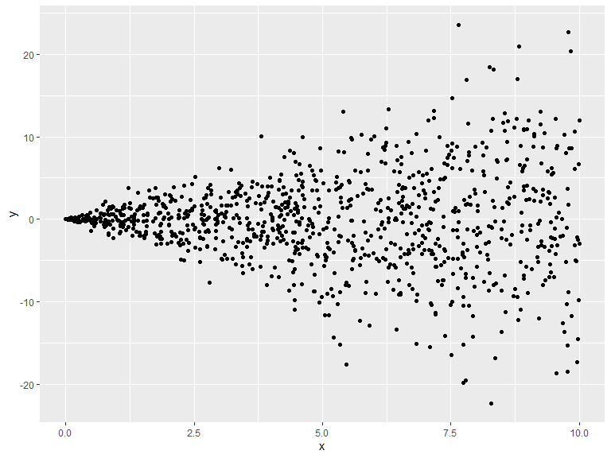

```r
x <- runif(1000, 0, 10)
y <- rnorm(1000, sd = x)
df <- data.frame(x,y)
ggplot(df, aes(x=x,y=y)) +
  geom_point()
```

## Let’s do some more simulations

```r
set.seed(12233)
df <- data.frame(matrix(ncol=1,nrow=1000))
colnames(df) <- c("p_value")
for(i in 1:nrow(df)) {
x <- runif(1000, 0, 10)
y <- rnorm(1000, sd=x)
lm2 <- lm(y ~ x)
#store p-value
df[i,1] <- summary(lm2)$coefficients[2,4]
}
```

```r
sum(df$p_value<.05)
```

```
## [1] 79
```

## We are clearly over-rejecting

- The heteroscedasticity is tricking our estimator into thinking there is less variation in x than there really is
- This makes coefficient estimates look more extreme than they really are
- We can then be fooled into thinking a relationship is significant when it’s not
- Fortunately, this has an easy fix

## Now let’s try ROBUST standard errors

```r
df <- data.frame(matrix(ncol=1,nrow=1000))
colnames(df) <- c("p_value")
for(i in 1:nrow(df)) {
x <- runif(1000, 0, 10)
y <- rnorm(1000, sd=x)
lm3 <- lm(y ~ x)
rob_std_errs <- coeftest(lm3, vcov = vcovHC(lm3, type = 'HC0'))
df[i,1] <- rob_std_errs[2,4]
}
```

```r
sum(df$p_value<.05)
```

```
## [1] 39
```

## So what happened here?

- OLS key assumption -> constant variance of DV
- Here we’ve made that assumption false
  - This breakdown causes it to look like there is *less* variation than there really is
  - This makes our standard errors more precise
- Would you have noticed this issue if you were just running regressions?

## We can also use simulations to test for *power*

- What is *statistical power*
  - The likelihood of a statistical test detecting an effect *when there actually is one*
  - Very important for RCT’s in order to know N needed
  - (and to get funding)

## Power Sim

```r
sims <- 1000
N <- 1000
effect <- .03

df <- data.frame(matrix(ncol=1,nrow=sims))
colnames(df) <- c("p_value")
for(i in 1:nrow(df)) {
x <- rnorm(N)
y <- rnorm(N) + effect*x
lm3 <- lm(y ~ x)
rob_std_errs <- coeftest(lm3, vcov = vcovHC(lm3, type = 'HC0'))
df[i,1] <- rob_std_errs[2,4]
}
length(df$p_value[df$p_value<.05])
```

```
## [1] 156
```

## Class Exercise

- Does it matter that we used robust standard errors here?
  - Did they change anything in the absence of heteroscedasticity
- Holding sims and N constant, how big of an effect do we need to get 50% power?
- Holding sims and effect constant, how big an N do we need to get 50% power?
- Does increasing the number of sims increase power?

## Answer 1

- It doesn’t look like it mattered much.
  - Can we get a little more clarification?

```r
sims <- 1000
N <- 1000
effect <- .03

df <- data.frame(matrix(ncol=1,nrow=sims))
colnames(df) <- c("p_value")
for(i in 1:nrow(df)) {
x <- rnorm(N)
y <- rnorm(N) + effect*x
lm3 <- lm(y ~ x)
#rob_std_errs <- coeftest(lm3, vcov = vcovHC(lm3, type = 'HC0'))
df[i,1] <- summary(lm3)$coefficients[2,4]
}
length(df$p_value[df$p_value<.05])
```

```
## [1] 165
```

## Meta Sim

```r
df_meta <- data.frame(matrix(ncol = 2, nrow= 100))
colnames(df_meta) <- c("reject","reject_robust")

for(meta_sim in 1:100) {
df <- data.frame(matrix(ncol=2,nrow=100))
colnames(df) <- c("p","p_robust")
for(i in 1:nrow(df)) {
x <- rnorm(N)
y <- rnorm(N) + effect*x
lm3 <- lm(y ~ x)
rob_std_errs <- coeftest(lm3, vcov = vcovHC(lm3, type = 'HC0'))
df[i,1] <- summary(lm3)$coefficients[2,4]
df[i,2] <- rob_std_errs[2,4]
}
df_meta[meta_sim,1] <- mean(df$p<.05)
df_meta[meta_sim,2] <- mean(df$p_robust<.05)
}
```

## Meta Sim Reject Rate Averages

```r
mean(df_meta$reject)
```

```
## [1] 0.1591
```

```r
mean(df_meta$reject_robust)
```

```
## [1] 0.1611
```

## Meta Sim Plot

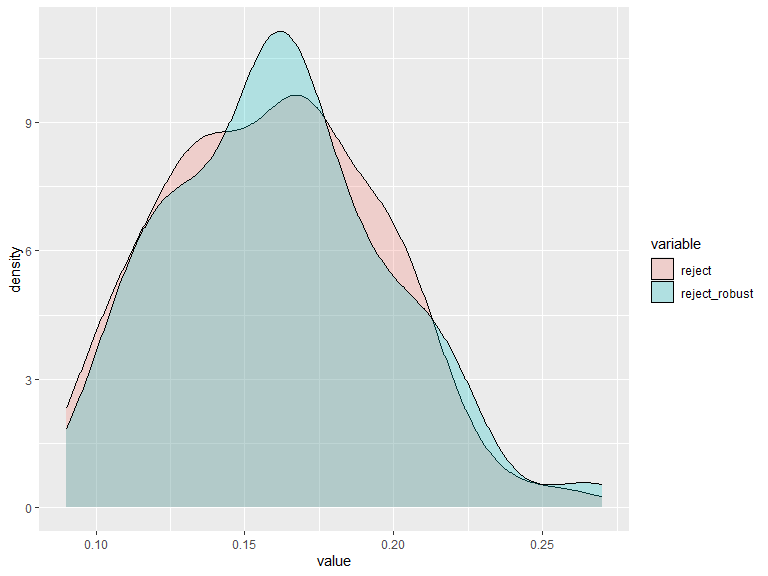

```r
data <- melt(df_meta)
ggplot(data, aes(x=value, fill=variable)) +
  geom_density(alpha=.25)
```

## Answer 2

- I get about .063

```r
sims <- 1000
N <- 1000
effect <- .063

df <- data.frame(matrix(ncol=1,nrow=sims))
colnames(df) <- c("p_value")
for(i in 1:nrow(df)) {
x <- rnorm(N)
y <- rnorm(N) + effect*x
lm3 <- lm(y ~ x)
#rob_std_errs <- coeftest(lm3, vcov = vcovHC(lm3, type = 'HC0'))
df[i,1] <- summary(lm3)$coefficients[2,4]
}
length(df$p_value[df$p_value<.05])
```

```
## [1] 486
```

## Answer 3

- I get about 4300

```r
sims <- 1000
N <- 4300
effect <- .03

df <- data.frame(matrix(ncol=1,nrow=sims))
colnames(df) <- c("p_value")
for(i in 1:nrow(df)) {
x <- rnorm(N)
y <- rnorm(N) + effect*x
lm3 <- lm(y ~ x)
#rob_std_errs <- coeftest(lm3, vcov = vcovHC(lm3, type = 'HC0'))
df[i,1] <- summary(lm3)$coefficients[2,4]
}
length(df$p_value[df$p_value<.05])
```

```
## [1] 490
```

## Answer 3 more formally

```r
sims <- 1000
effect <- .03
N_seq <- seq(1000,10000,200)

df_N <- data.frame(matrix(ncol=2,nrow=length(N_seq)))
colnames(df_N) <- c("power","obs")
j <- 1

for(n in N_seq) {
N <- n
df <- data.frame(matrix(ncol=1,nrow=sims))
colnames(df) <- c("p_value")
for(i in 1:nrow(df)) {
x <- rnorm(N)
y <- rnorm(N) + effect*x
lm3 <- lm(y ~ x)
#rob_std_errs <- coeftest(lm3, vcov = vcovHC(lm3, type = 'HC0'))
df[i,1] <- summary(lm3)$coefficients[2,4]
}
df_N[j,1] <- sum(df$p_value<.05)/length(df$p_value)
df_N[j,2] <- n
j <- j + 1
}
```

## Answer 3 Visually

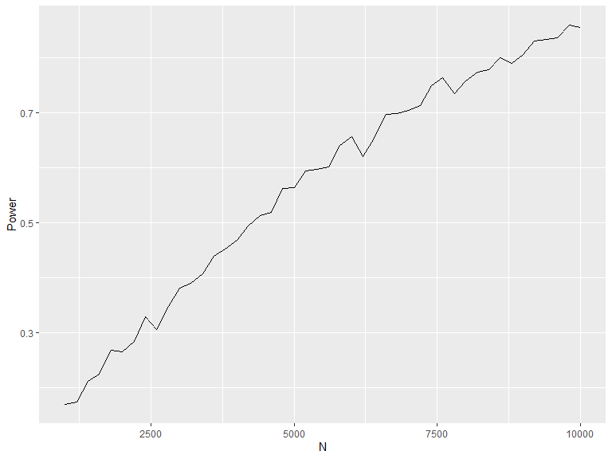

```r
ggplot(df_N, aes(x=obs,y=power)) +
  geom_line() + ylab("Power") + xlab("N")
```

## Answer 4

- Not really
  - What does this tell us?

```r
sims <- 5000
N <- 1000
effect <- .03

df <- data.frame(matrix(ncol=1,nrow=sims))
colnames(df) <- c("p_value")
for(i in 1:nrow(df)) {
x <- rnorm(N)
y <- rnorm(N) + effect*x
lm3 <- lm(y ~ x)
#rob_std_errs <- coeftest(lm3, vcov = vcovHC(lm3, type = 'HC0'))
df[i,1] <- summary(lm3)$coefficients[2,4]
}
length(df$p_value[df$p_value<.05])/(sims/1000)
```

```
## [1] 161.6
```

## Shifting gears to standard error best practices

- We will almost always need to make some adjustment
- Homoscedasticity assumption not really realistic
- All kinds of other problems as well

## Baseline - always start with robust SE’s

- Heteroscedasticity makes it look like there is less variation than there really is
- Robust standard errors address this by allowing $\sigma$ to vary
- Easy
  - For a better explanation, see CI: Mixtape, 2.26

## What about clustering?

- Often there will be groups in our data with common features
- Examples: classrooms, states, firms
- When groups have common features, they tend to have similar outcomes
  - This makes it look like there is less variation in $u$ than there really is

## Hence clustered standard errors

- Clustered SE’s allow for correlation of $u$ within clusters
- This fixes this problem and gives us consistent SE’s
  - Need to have a lot of clusters
  - No set rule, but 30-50 is a good rule of thumb
  - Should be clustered at the level of treatment

## So how do we do this?

```r
state <- round(runif(1000,.5,50.5))
x <- rnorm(1000)
y <- rnorm(1000) + x + state
lm <- lm(y~x + factor(state))
summary(lm)$coef[2,1-4]
```

```
##      Estimate    Std. Error      Pr(>|t|)
##  9.717463e-01  3.407433e-02 1.067648e-129
```

```r
clust_std_errors <- coeftest(lm, vcov = vcovCL, cluster= ~state)
clust_std_errors[2,1-4]
```

```
##     Estimate   Std. Error     Pr(>|t|)
## 9.717463e-01 4.322081e-02 4.438161e-90
```